None

*This notebook contains material from CBE30338; content is available [on Github](https://github.com/jckantor/CBE30338.git).*

< [3.3 Linear Approximation of a Multivariable Model](https://jckantor.github.io/CBE30338/03.03-Linear-Approximation-of-a-Multivariable-Model.html) | Contents | Tag Index | [3.5 One Compartment Pharmacokinetics](https://jckantor.github.io/CBE30338/03.05-One-Compartment-Pharmacokinetics.html) >

# 3.4 Fitting First Order plus Time Delay to Step Response

## 3.4.1 Summary

Linear first order plus time delay (FOPTD) models are often good approximations to process dynamics for process control applications. This notebook demonstrates the fitting of FOPTD models to step response data.

## 3.4.2 Initializations

```python
%matplotlib inline
import numpy as np
import matplotlib.pyplot as plt
import control
from scipy.optimize import minimize
```

## 3.4.3 First Order plus Time Delay Models

### 3.4.3.1 First Order Models

A linear first-order plus time-delay model is a good approximation for many process control applications. Assume the manipulated process input, $u$, and measured process output, $y$, are initially at steady-state $u_0, y_0$.

Without loss of generality, the response of a linear first-order system without time-delay can be written as a differential equation

$$\tau\frac{d(y-y_0)}{dt} + (y-y_0) = K(u-u_0)$$

or

$$\tau\frac{dy}{dt} + (y-y_0) = K(u-u_0)$$

At time $t_0$, the input $u$ is changed to a new constant value $u_\infty$. Provided the system is stable (i.e, $\tau \geq 0$), the new steady state value of $y$ will be

$$y_\infty = y_0 + K(u_\infty - u_0)$$

The solution to the differential equation can be written in a number of useful forms.

\begin{align*} y(t) & = y_0 + K(u_\infty - u_0) (1 - e^{-(t-t_0)/\tau)}) \\ \\ & = y_0 + (y_\infty - y_0) (1 - e^{-(t-t_0)/\tau)}) \\ \\ & = y_\infty + (y_0 - y_\infty)e^{-(t-t_0)/\tau)} \end{align*}

### 3.4.3.2 Time Delay

Chemical processes are frequently encumbered with time delays associated with the transport of materials, chemical measurement, or simply sluggish response to control inputs. A pure time delay is modeled by a single parameter, $\tau_d$, such that

$$y(t) = u(t-\tau_d)$$

### 3.4.3.3 First Order plus Time Delay (FOPTD)

If we add the time delay feature to the first order process described above, then

\begin{align*} y(t) & = y_0 + K(u_\infty - u_0) (1 - e^{-(t-\tau_d - t_0)/\tau)}) \\ \\ & = y_0 + (y_\infty - y_0) (1 - e^{-(t-\tau_d-t_0)/\tau)}) \\ \\ & = y_\infty + (y_0 - y_\infty)e^{-(t-\tau_d-t_0)/\tau)} \end{align*}

### 3.4.3.4 Visualization

First we write a function to compute the response of a first order system with time delay to a unit step input where $u_0 = 0$ and $u_\infty = 1$.

```python
def foptd(t, K=1, tau=1, tau_d=0):
    tau_d = max(0,tau_d)
    tau = max(0,tau)
    return np.array([K*(1-np.exp(-(t-tau_d)/tau)) if t >= tau_d else 0 for t in t])
```

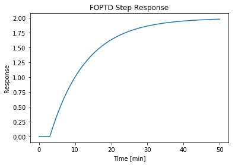

```python
t = np.linspace(0,50,200)
tau = 10
tau_delay = 3
K = 2

y = foptd(t,K,tau,tau_delay)
plt.plot(t,y)
plt.xlabel('Time [min]')
plt.ylabel('Response')
plt.title('FOPTD Step Response')
```

## 3.4.4 Fitting an FOPTD model

### 3.4.4.1 Sample Problem Statement

The problem task to fit a FOPTD model to this experimental result.

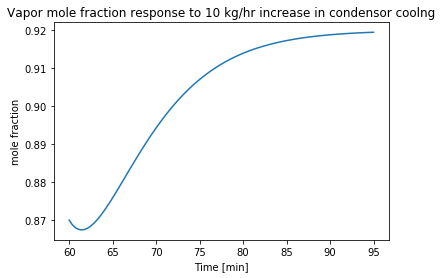

```python
# create the hypothetical problem data
delta_y,t = control.step(0.05*control.tf([-2, 1],[25, 10, 1]))
y = 0.87 + delta_y
t = t + 60

plt.plot(t,y)
plt.xlabel('Time [min]')
plt.ylabel('mole fraction')
plt.title('Vapor mole fraction response to 10 kg/hr increase in condensor coolng')
```

### 3.4.4.2 Step 1. Shift and scale the experimental data to correspond to a unit step input at time t = 0.

The first step is to scale the experimental data to fit the framework of an FOPTD model. This generally involves three steps:

- Shift the time scale to t = 0 corresponds to the start of the experiment.

$$ t_s = t - t_0$$

- Shift the response so y = 0 is the initial steady state
- Rescale the response to a unit change in input

$$ y_s = \frac{y(t) - y_0}{u_\infty - u_0}$$

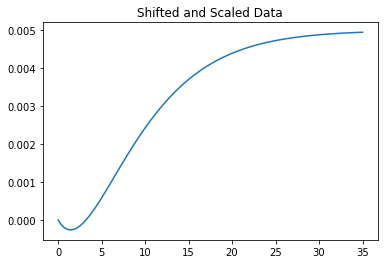

```python
ts = t - t[0]
ys = (y - y[0])/(120 - 110)

plt.plot(ts, ys)
plt.title('Shifted and Scaled Data')
```

### 3.4.4.3 Step 2. Create a function to compute the response of an FOPTD model.

For a given list of times $t$ and parameters $K$, $\tau$, and $\tau_d$, the `foptd` returns the response of an FOPTD system to a unit change in input at $t = 0$.

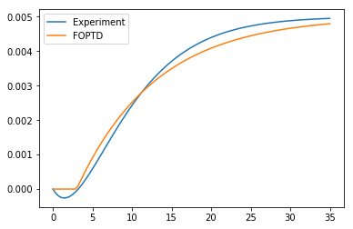

```python
def foptd(t, K=1, tau=1, tau_d=0):
    tau_d = max(0,tau_d)
    tau = max(0,tau)
    return np.array([K*(1-np.exp(-(t-tau_d)/tau)) if t >= tau_d else 0 for t in t])

z = foptd(ts, 0.005, 10, 3)
plt.plot(ts,ys,ts,z)
plt.legend(['Experiment','FOPTD'])
```

### 3.4.4.4 Step 3. Create a function to measure the error between an FOPTD model and the experimental data.

Let's called the step response of the fitted model to be $\hat{y}_s$. We seek to minimize

$$\min_{K,\tau,\tau_d} \int_0^T \|\hat{y}_s - y_s\|\,dt$$

for some suitable norm $\|\cdot\|$. A common choice of norm for process control is the absolute value of the difference called Integral Absolute Error (IAE)

$$\text{IAE} = \min_{K,\tau,\tau_d} \int_0^T |\hat{y}_s - y_s|\,dt$$

The advantage of IAE over other choices of norms is that it tends to be more robust with respect to larger errors.

```python
def err(X,t,y):
    K,tau,tau_d = X
    z = foptd(t,K,tau,tau_d)
    iae = sum(abs(z-y))*(max(t)-min(t))/len(t)
    return iae

X = [0.005,10,3]
err(X,ts,ys)
```

```
0.0077632135835474644
```

### 3.4.4.5 Step 4. Use scipy.optimize.minimize() to find the best fitting FOPTD model.

```python
K,tau,tau_d = minimize(err,X,args=(ts,ys)).x

print("K = {:.5f}".format(K))
print("tau = {:.2f}".format(tau))
print("tau_d = {:.2f}".format(tau_d))
```

```
K = 0.00512
tau = 8.04
tau_d = 4.61
```

### 3.4.4.6 Step 5. Rescale FOPTD output and compare to experimental data.

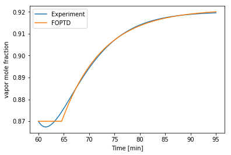

```python
z = foptd(ts,K,tau,tau_d)
ypred = y[0] + z*(120 - 110)

plt.plot(t,y,t,ypred)
plt.xlabel('Time [min]')
plt.ylabel('vapor mole fraction')
plt.legend(['Experiment','FOPTD'])
```

< [3.3 Linear Approximation of a Multivariable Model](https://jckantor.github.io/CBE30338/03.03-Linear-Approximation-of-a-Multivariable-Model.html) | Contents | Tag Index | [3.5 One Compartment Pharmacokinetics](https://jckantor.github.io/CBE30338/03.05-One-Compartment-Pharmacokinetics.html) >